# kolokvij_1

## Transformacije

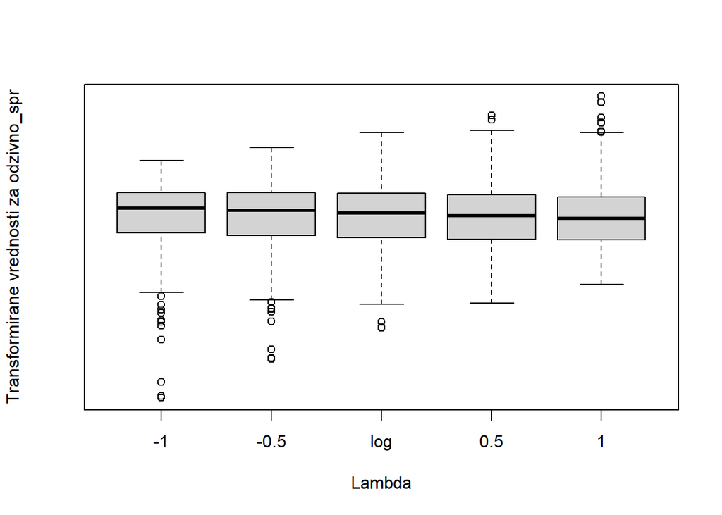

```r
# Izbira transformacije
symbox(~ FEV, xlab = "Lambda",
ylab = "Transformirane vrednosti za odzivno_spr",
data = data) # Izbereš tisto, kjer je boxplot najbolj simetričen, najbolj podoben ~ N
```

```r
# Oceni, katera lambda bi bila glede na maximum likelihood primerna
summary(powerTransform(model)) # razlaga spodaj
```

```
## bcPower Transformation to Normality
##    Est Power Rounded Pwr Wald Lwr Bnd Wald Upr Bnd
## Y1     0.385         0.5       0.2194       0.5506
##
## Likelihood ratio test that transformation parameter is equal to 0
##  (log transformation)
##                            LRT df       pval
## LR test, lambda = (0) 21.18225  1 4.1762e-06
##
## Likelihood ratio test that no transformation is needed
##                            LRT df       pval
## LR test, lambda = (1) 51.09044  1 8.8207e-13
```

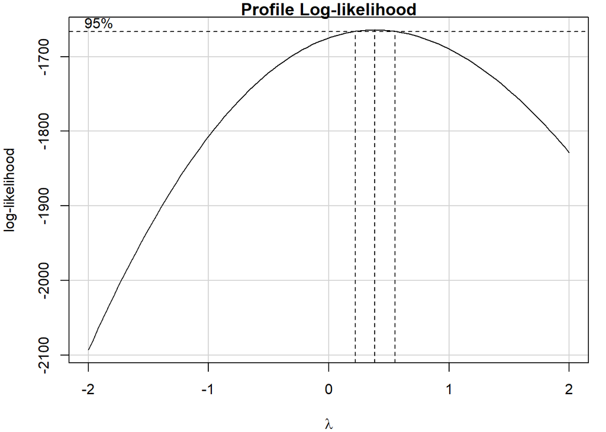

```r
# Logaritem verjetja v odvisnosti od 𝜆 za model, optimalna vrednost za 𝜆 in njen 95 % IZ
par(mar = c(4, 4, 1, 1))
boxCox(model) # Pazi pri teh transformacijah, včasih ni razložljivo!
```

```r
################################################################################

# Interpretacija eksponentne zveze:
model_exp = lm(log(FEV) ~ Age*Ht*Gender*Smoke, data = data)
(b = coefficients(model_exp))
```

```
##                (Intercept)                        Age
##              -2.546366e+00               1.214529e-01
##                         Ht                GenderMoški
##               2.048760e-02               9.803390e-01
##                    SmokeDa                     Age:Ht
##               1.205434e+01              -6.002722e-04
##            Age:GenderMoški             Ht:GenderMoški
##              -1.371291e-01              -5.876108e-03
##                Age:SmokeDa                 Ht:SmokeDa
##              -8.365651e-01              -7.146759e-02
##        GenderMoški:SmokeDa         Age:Ht:GenderMoški
##              -1.387799e+01               8.444211e-04
##             Age:Ht:SmokeDa    Age:GenderMoški:SmokeDa
##               4.930763e-03               8.748089e-01
##     Ht:GenderMoški:SmokeDa Age:Ht:GenderMoški:SmokeDa
##               8.235677e-02              -5.194288e-03
```

```r
exp(b[1]) # Eksponiraj intercept (beta0) → Interpretacija je zdaj lahko: Ob napovedni_spr = 0, je odzivna_spr enaka exp(b[1]).
```

```
## (Intercept)
##  0.07836594
```

```r
exp(confint(model_exp)[1,]) # Eksponiraj IZ za intercept
```

```
##      2.5 %     97.5 %
## 0.04208396 0.14592784
```

```r
exp(b[2])-1 # Eksponiraj beta1 → interpretacija je zdaj lahko: Če se napovedna_spr spremeni za 1, se odzivna_spr spremeni za exp(b[2])-1 * 100 %.
```

```
##       Age
## 0.1291362
```

```r
exp(confint(model_exp)[2,])-1 # Eksponiraj IZ za beta1
```

```
##     2.5 %    97.5 %
## 0.0415575 0.2240789
```

```r
summary(model_exp)$r.squared
```

```
## [1] 0.8189491
```

```
## NOTE: HtAgeSmokeGender does not appear in the model
```

```
## NOTE: HtAgeSmokeGender is not a high-order term in the model
```

[figure not shown]

```r
# Grafični prikazi za exp zvezo

## 1.1 način
plot(effect(c("Ht", "Age", "Smoke", "Gender"), model_exp,
            transformation = list(link = log, inverse = exp)),
     axes = list(y = list(lab = "odzivna_spr")), main = "") # Odvisnost odzivne_spr od napovedna_spr in pripadajoča regresijska premica s 95 % IZ za povprečno napoved odzivne_spr, skala za odzivno_spr je logaritemska!!!!
```

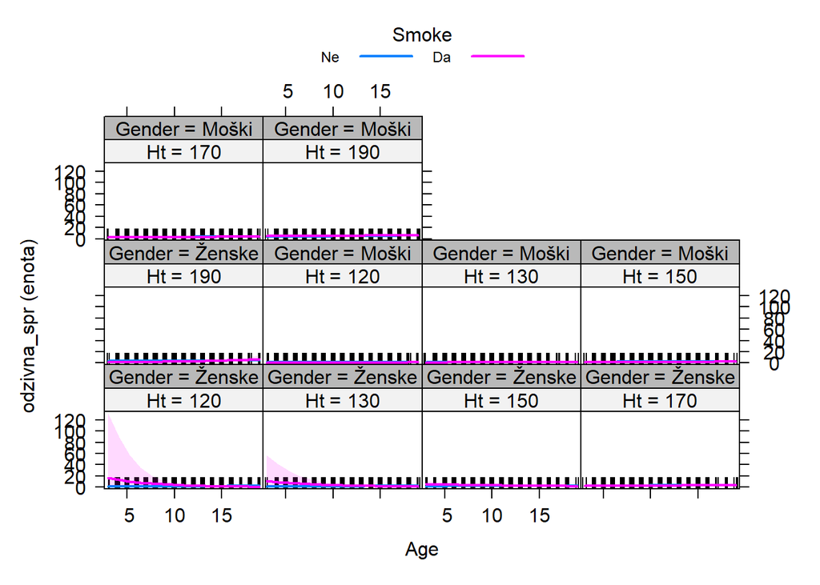

```r
## 1.2 način
plot(Effect(c("Age", "Ht", "Smoke", "Gender"), model_exp,
            transformation = list(link = log,inverse = exp)),
     axes = list(y = list(lab = "odzivna_spr (enota)", type = "response")),
     multiline=TRUE, ci.style="bands", main="")
```

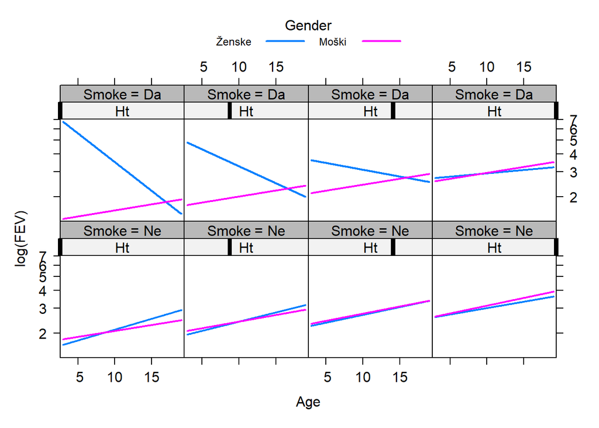

```r
plot(Effect(c("Age","Ht","Gender","Smoke"), model_exp, partial.residuals=TRUE, transformation = list(link = log,inverse = exp)), main="", multiline = TRUE)
```

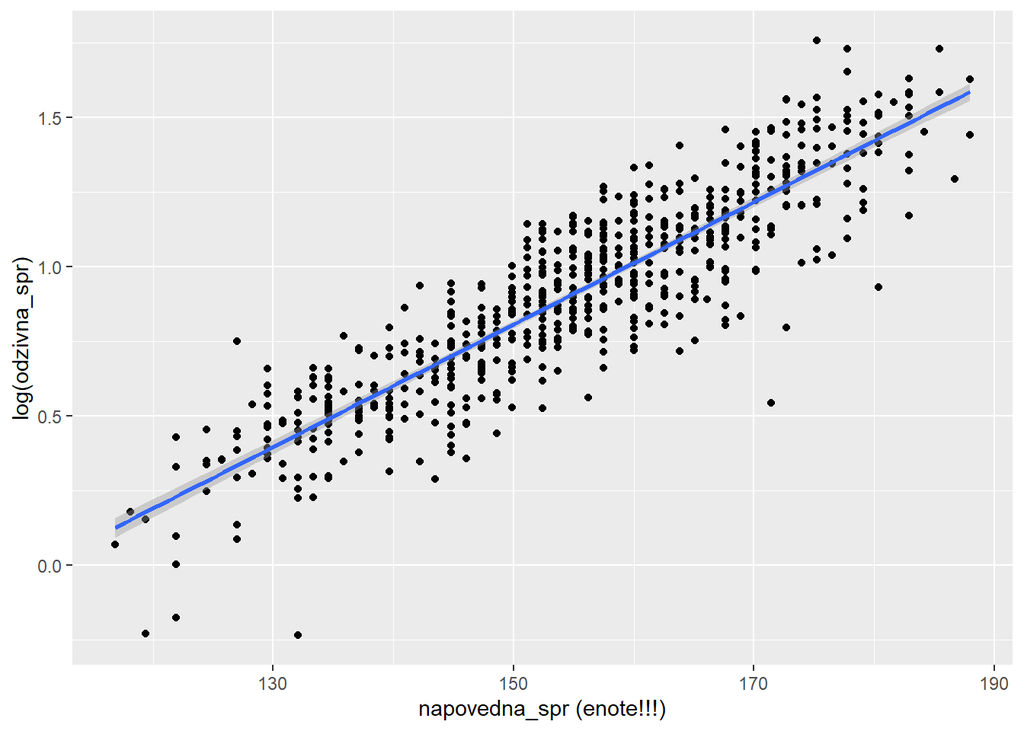

```r
## 2. način
ggplot(data = data, aes(x = Ht, y = log(FEV))) +
geom_point() + stat_smooth(method = "lm") +
xlab("napovedna_spr (enote!!!)") + ylab("log(odzivna_spr)") # Odvisnost log(odzivna_spr) od napovedna_spr in pripadajoča regresijska premica s 95 % IZ za povprečno napoved log(odzivna_spr)
```

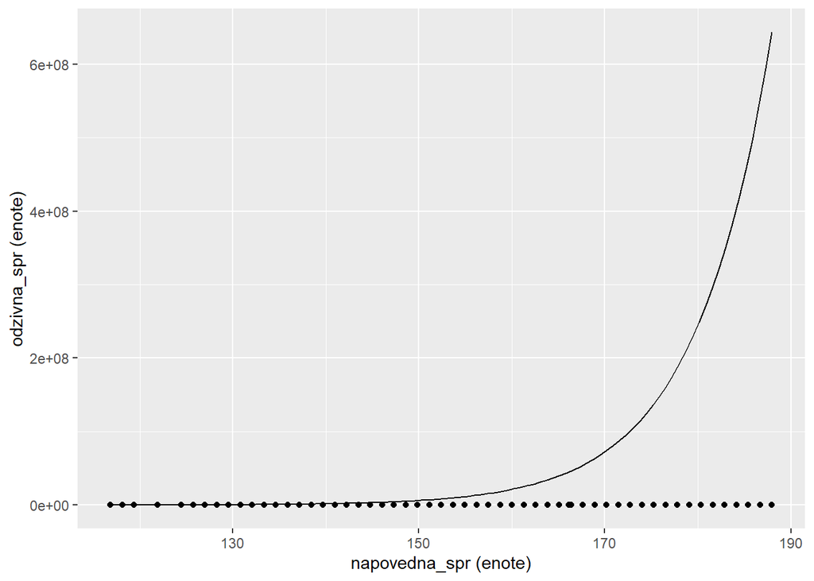

```r
# Grafični prikazi (de-transformacija) za exp zvezo
ggplot(data = data, aes(x = Ht, y = FEV)) +
  geom_point() + xlab("napovedna_spr (enote)") + ylab("odzivna_spr (enote)") +
  stat_function(fun = function(Ht) exp(b[1] + b[2] * Ht)) #  Odvisnost odzivna_spr od napovedna_spr; eksponentni model
```

- powerTransform razlaga: poiščemo parametre pri katerih je verjetje za y največje. Oceno 𝜆̂ dobimo z numeričnim postopkom kjer za različne vrednosti 𝜆̂ izračunamo verjetje za y. Izberemo 𝜆, pri kateri ima logaritem verjetja maksimalno vrednost. powerTransform vrne optimalni 𝜆 in pripadajoči IZ ter izvede dva informativna testa: **𝐻0∶ 𝜆 = 0 (ustrezna je logaritemska transformacija)** 𝐻0∶ 𝜆 = 1 (𝑦 ni treba transformirati)

## Vizualizacije modelov

```r
head(model.matrix(model)) # da preveriš referenčne skupine
```

```
##   (Intercept) GenderMoški Age GenderMoški:Age
## 1           1           0   3               0
## 2           1           0   4               0
## 3           1           0   4               0
## 4           1           0   4               0
## 5           1           0   4               0
## 6           1           0   4               0
```

```r
tail(model.matrix(model))
```

```
##     (Intercept) GenderMoški Age GenderMoški:Age
## 649           1           1  16              16
## 650           1           1  16              16
## 651           1           1  17              17
## 652           1           1  17              17
## 653           1           1  18              18
## 654           1           1  18              18
```

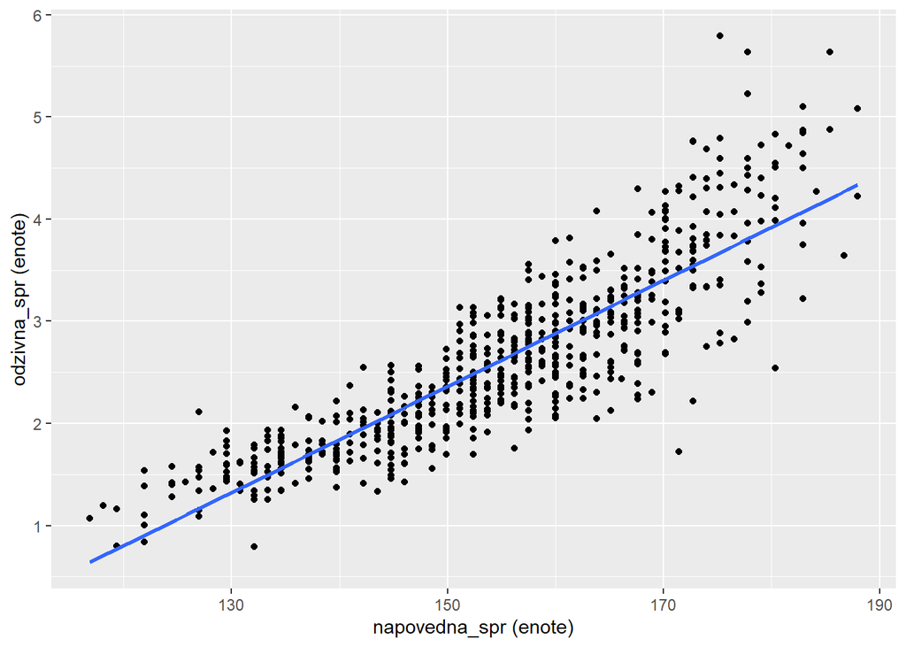

```r
# Dodatek regresijske premice na razsevni grafikon
ggplot(data = data, mapping = aes(x = Ht, y = FEV)) +
geom_point() +
geom_smooth(method = "lm", se = FALSE) + # če daš se=TRUE dobiš 95% IZ za povprečno napoved!!
xlab("napovedna_spr (enote)") + ylab("odzivna_spr (enote)")
```

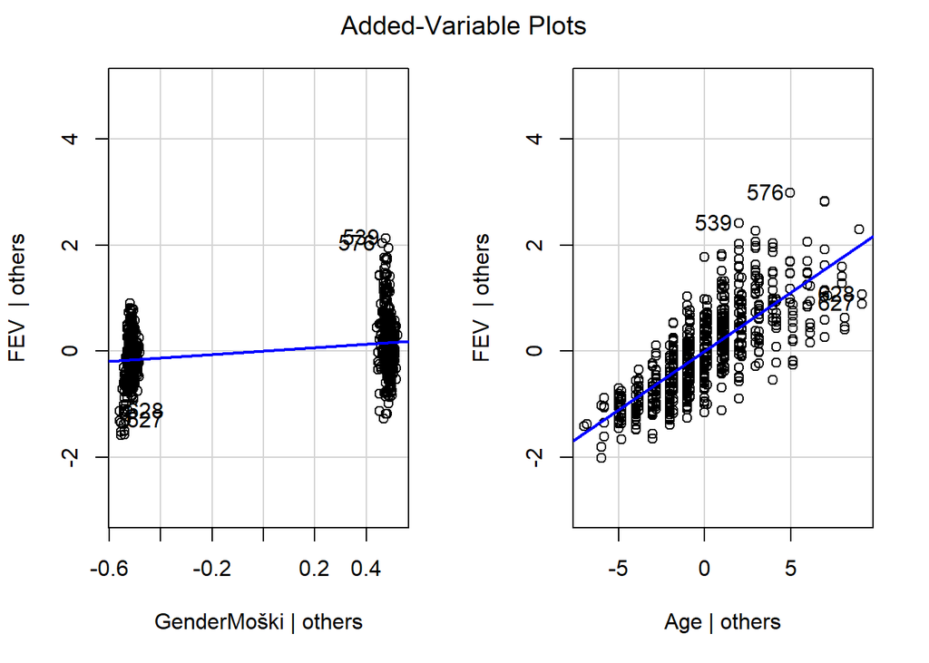

```r
# Graf dodane spremenljivke
avPlots(m1, ylim = c(-3, 5)) # Vpliv vsake od napovednih spr na odzivno spr ob upoštevanju ostalih spr v modelu (= pri konstantni vrednosti ostalih spr) - naklon je enak oceni parametrov za tisto spremenljivko
```

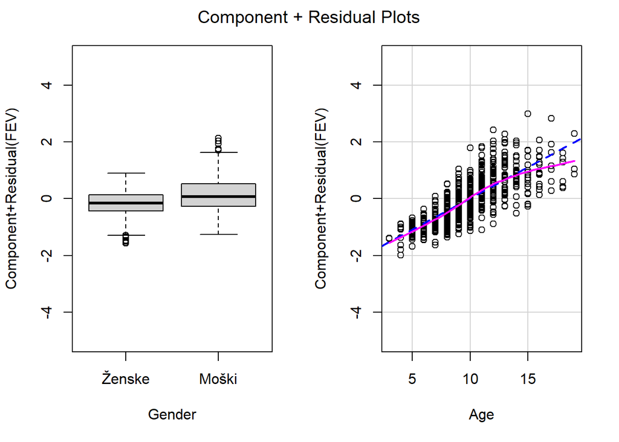

```r
# 3D grafikon za dve številski spremenljivki hkrati
# avPlot3d(mod2, coef1="Age", coef2="Ht")

# Graf parcialnih ostankov
crPlots(m1, ylim = c(-5, 5))# Odvisnosti odzivne spr od posamezne napovedne spr upoštevajoč drugo/-e spr v modelu → BREZ INTERAKCIJ
```

[figure not shown]

```r
plot(Effect(c("Age", "Ht", "Gender", "Smoke"), model_exp), partial.residuals = TRUE, multiline=FALSE,
     ci.style="bands", main="", ylim=c(-3,3)) #  Modelske napovedi za odzivno_spr v odvisnosti od spr1, spr2 in spr3 hkrati, pri povprečni vrendosti spr4 za model → Z INTERAKCIJAMI (iste grafe narišeš pred in po vključitvijo interakcij!!) → glej interakcije
```

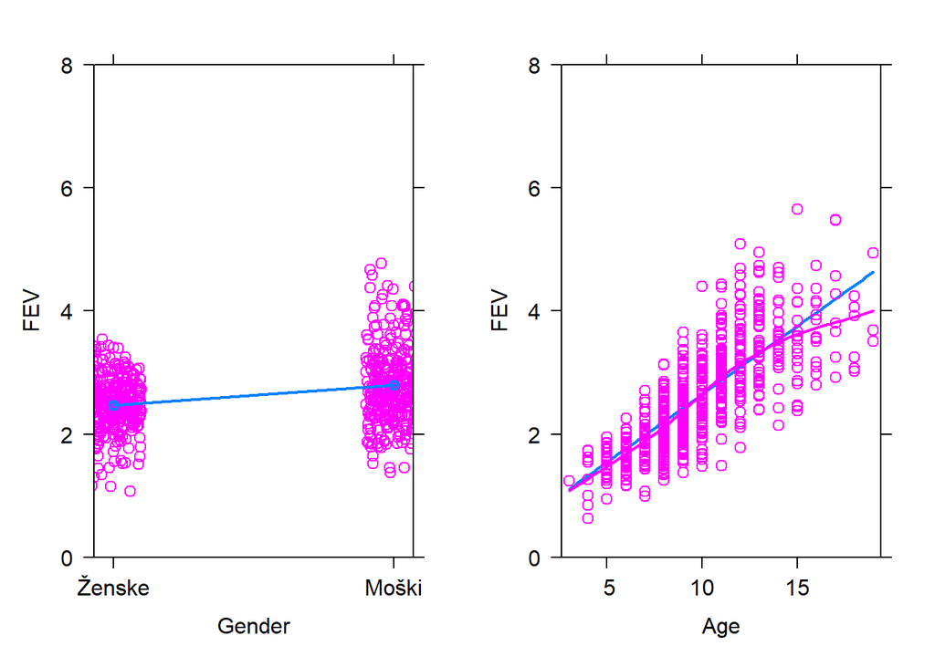

```r
# Druga možnost grafa parcialnih ostankov
plot(predictorEffects(m1, ~., partial.residuals = TRUE),
ci.style = "none", ylim = c(0, 8), main = "") # Napovedane vrednosti za povprečno odzivno_spr za m1 in parcialni ostanki z gladilnikom; levo: glede na napovedno_spr1 pri povprečni napovedni_spr2, desno: glede na napovedno_spr2 pri povprečni napovedni_spr1.
```

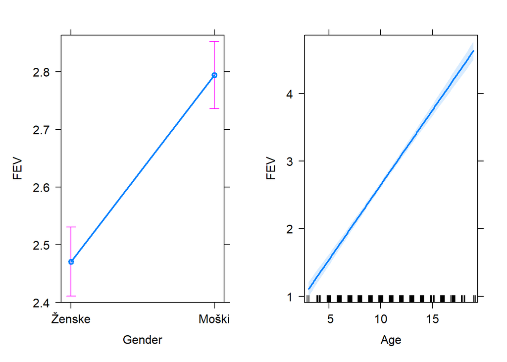

```r
# Grafični prikaz napovedi in pripadajočih intervalov zaupanja za povprečne napovedi
plot(predictorEffects(m1, ~.), main = "") # Napovedane vrednosti in 95 % intervali zaupanja za povprečno odzivno_spr za m1; levo: glede na napovedno_spr1 pri povprečni napovedni_spr2, desno: glede na napovedno_spr2 pri povprečni napovedni_spr1.
```

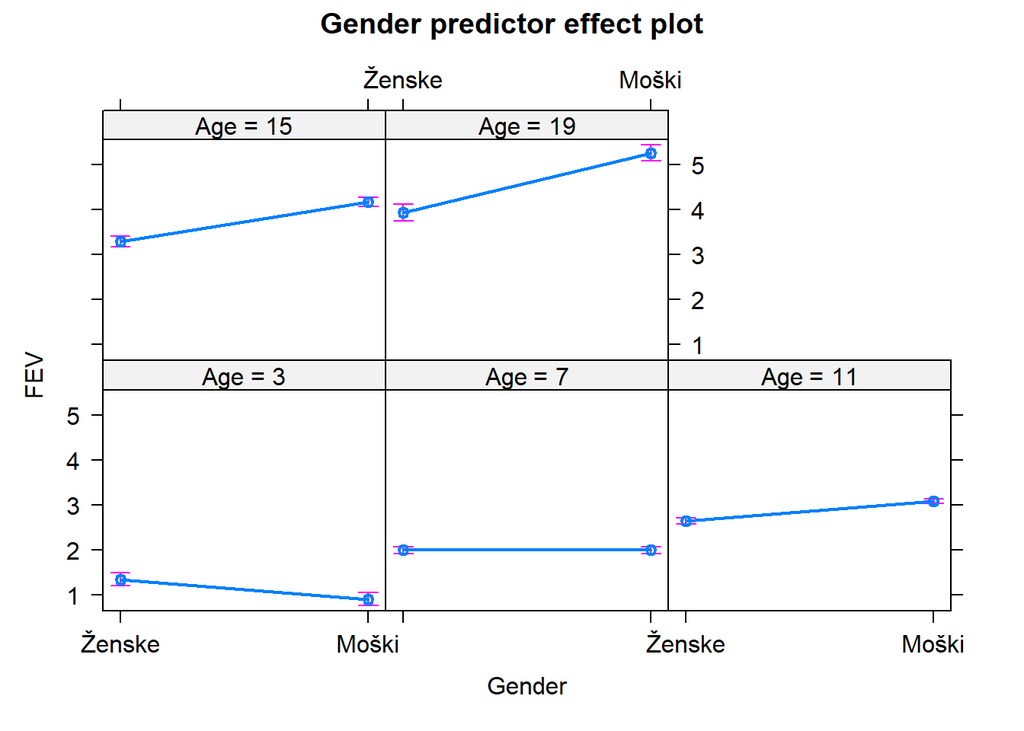

```r
#!!! graf parcialnih ostankov razlaga:
plot(predictorEffect(c("Gender"), model))
```

```r
# Razlaga: Povprečne napovedi za odzivno_spr (y os) v odvisnosti od napovedne_spr1 (x os) in napovedne_spr2 (več grafov glede na to spr - vrednosti v naslovih grafov) pri povprečni vrednosti napovedne_spr3.
```

Razlaga:

*crPlots: Za številske regresorje modra črtkana premica prikazuje modelske napovedi odzivne_spr glede na vrednosti posameznega regresorja pri povprečnih vrednostih ostalih regresorjev; točke predstavljajo parcialne ostanke za regresor, ki je na vodoravni osi. Gladilnik je narisan na podlagi parcialnih ostankov.